# Bulk RNAseq analysis

Alex Thiery

2023-01-20

### **R tutorial 2**

Previously we conducted differential expression analysis using DESeq2. Now, we will visualise these results in volcano plots and heatmaps using ggplot2.

#### **Setup working environment**

```r
knitr::opts_knit$set(root.dir = '~/Downloads/')
```

Set working directory

```r
setwd('~/Downloads/')
```

Load libraries

```r
if (!require("pheatmap", quietly = TRUE)){
    install.packages("pheatmap", repos = "http://cran.us.r-project.org")
}

if (!require("ggplot2", quietly = TRUE)){
    install.packages("ggplot2", repos = "http://cran.us.r-project.org")
}

library(pheatmap)
library(ggplot2)
library(DESeq2)
library(dplyr)
```

Set output path

```r
output_path <- './output/'
```

#### **Volcano Plot**

The first thing we need to do is read in the deseq2 output that we made in session 1:

```r
deseq <- readRDS(paste0(output_path, 'deseq_output.RDS'))
res <- lfcShrink(deseq, coef=c("Group_MCF7_vs_H1"), type = 'apeglm')
```

```
## using 'apeglm' for LFC shrinkage. If used in published research, please cite:
##     Zhu, A., Ibrahim, J.G., Love, M.I. (2018) Heavy-tailed prior distributions for
##     sequence count data: removing the noise and preserving large differences.
##     Bioinformatics. https://doi.org/10.1093/bioinformatics/bty895
```

```r
rld <- rlog(deseq)
```

Then we need to format this data so we can plot it.

```r
volcano_data <- as.data.frame(res)

volcano_data <- mutate(volcano_data, '-log10(padj)' = -log10(padj))
```

Then we use the ggplot package to plot the data.

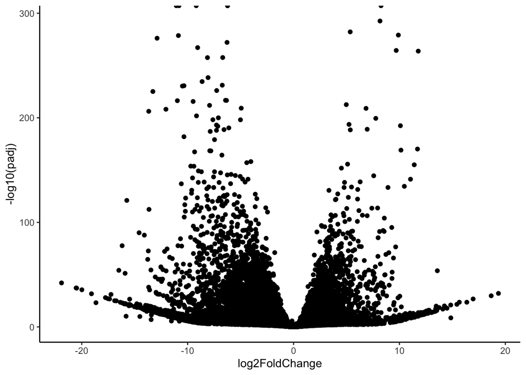

```r
ggplot(volcano_data, aes(log2FoldChange, `-log10(padj)`)) +
  geom_point() +
  theme_classic()
```

#### **Volcano Plot with thresholds**

We can upgrade our volcano plots by colouring our points based on log2FC or p-values. This can make it easier to quickly spot which genes are significantly upregulated or downregulated.

To plot which genes are significant, we first need to threshold the results so we label any genes which hav a p-value of less than 0.001.

```r
volcano_data <- volcano_data %>%
  filter(!is.na(padj)) %>%
  mutate(sig = case_when((padj < 0.001) == 'TRUE' ~ 'significant',
                         (padj >= 0.001) == 'TRUE' ~ 'not sigificant')) %>%
  arrange(abs(padj))
```

Next, we can colour the genes according to their significance. Let’s colour the genes that are significant blue and those that are not significant grey. We can also use `geom_hline` to add a horizontal line at our p-value threshold on the y axis.

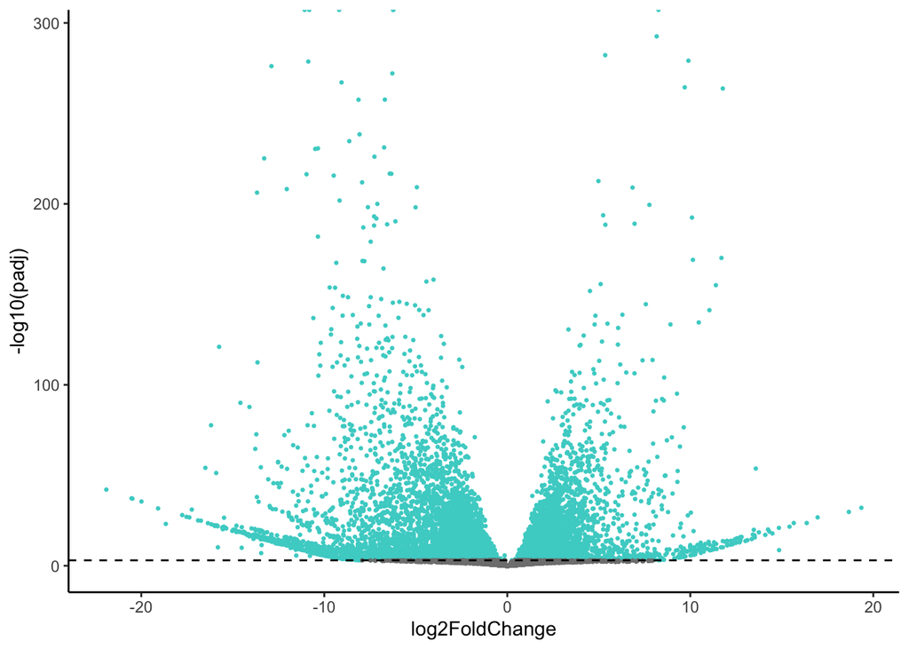

```r
ggplot(volcano_data, aes(log2FoldChange, `-log10(padj)`)) +
  geom_point(aes(colour = sig, fill = sig), size = 0.5) +
  scale_color_manual(breaks = c("not sig", "significant"),
                    values = alpha(c("#c1c1c1", "#48d1cc"))) +
  geom_hline(yintercept=-log10(0.001), linetype="dashed", color = "black") +
  theme_classic() +
  theme(legend.position = "none")
```

#### Challenge: Make a volcano plot where significantly upregulated genes (with a p-value of less than 0.001 and a log2FC of more than 2.5) are colored in blue, significantly downregulated genes (p-value less than 0.001 and log2FC less than -2.5) are coloured red, and non-significant genes (p-value more than 0.001) are grey.

TIP: use the code above as a guide, you just need to add some extra code to separate the significant genes based on whether they are upregualated or downregulated.

Here we use the operators AND `&` and OR `|` to help us categorise our genes into ‘upregulated’, ‘downregulated’ and ‘not sig’. These points are then coloured in ggplot and `geom_hline` and `geom_vline` are used to add lines where our thresholds are.

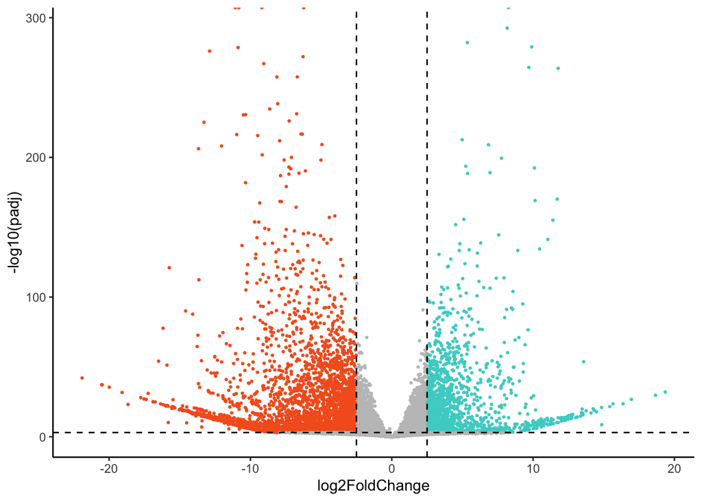

```r
volcano_data <- volcano_data %>%
  filter(!is.na(padj)) %>%
  mutate(sig = case_when((padj < 0.001 & log2FoldChange > 2.5) == 'TRUE' ~ 'upregulated',
                         (padj < 0.001 & log2FoldChange < -2.5) == 'TRUE' ~ 'downregulated',
                         (padj >= 0.001 | abs(log2FoldChange) <= 2.5) == 'TRUE' ~ 'not sig')) %>%
  arrange(abs(padj))

ggplot(volcano_data, aes(log2FoldChange, `-log10(padj)`)) +
  geom_point(aes(colour = sig, fill = sig), size = 0.5) +
  scale_color_manual(breaks = c("not sig", "downregulated", "upregulated"),
                    values = alpha(c("#c1c1c1", "#f55f20", "#48d1cc"))) +
  geom_hline(yintercept=-log10(0.001), linetype="dashed", color = "black") +
  geom_vline(xintercept=c(-2.5, 2.5), linetype="dashed", color = "black") +
  theme_classic() +
  theme(legend.position = "none")
```

#### **Heatmap of top differentially expressed genes**

As well as volcano plots, we can visualise the expression levels of genes across samples using a heatmap.

First lets subset our differentially expressed genes (adjusted p-value < 0.001, absolute log2FC > 2.5).

```r
res_sub <- filter(as.data.frame(res), padj < 0.001 & abs(log2FoldChange) > 2.5)
res_sub <- res_sub[order(-res_sub$log2FoldChange),]
res_sub[1:10,]
```

```
##                 baseMean log2FoldChange    lfcSE       pvalue         padj
## DSCAM-AS1     11852.4015       19.34800 3.901098 5.561625e-34 9.048089e-33
## AGR2           7643.3395       18.66513 3.847486 1.191431e-31 1.738579e-30
## AREG           3723.1641       16.95741 3.066784 1.459428e-28 1.854429e-27
## SLC6A14        1837.7563       16.36194 3.558816 2.218932e-25 2.426492e-24
## AL589743.1     3531.8698       15.65411 2.829704 2.220707e-25 2.427255e-24
## S100P          1311.5686       15.42381 3.143346 2.562924e-23 2.493812e-22
## AP000525.9     1799.1801       14.85335 3.571602 5.858889e-10 2.300641e-09
## CTD-2314B22.3  1539.1705       14.84304 2.880316 1.249878e-22 1.170156e-21
## AGR3            547.6720       14.48861 3.473373 1.817980e-19 1.413943e-18
## TPTE            751.4706       14.32056 3.050816 1.620094e-20 1.343080e-19
```

Now we can plot a heatmap of our differentially expressed genes.

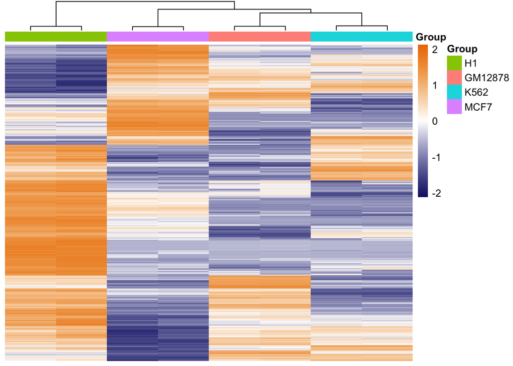

```r
pheatmap(assay(rld)[rownames(res_sub),], color = colorRampPalette(c("#191d73", "white", "#ed7901"))(n = 100), cluster_rows=T, show_rownames=FALSE,
         show_colnames = F, cluster_cols=T, annotation_col=as.data.frame(colData(deseq)["Group"]), scale = "row", treeheight_row = 0, treeheight_col = 25,
         border_color = NA)
```